# Practice Exam

$$\text{Name:\_\_\_\_\_\_\_\_\_\_\_\_\_\_\_\_\_\_\_\_\_\_\_\_\_\_\_\_\_\_\_\_\_\_\_\_\_}$$

# Directions

- You **do not** need to fill all the space provided. In many cases, large amounts of white space only exist to correct for general spacing of the exam
- You **do not** need to write in complete sentences for all questions: if I desire you to answer in a complete sentence I will indicate this
- The practice exam is shorter than the actual exam
- The actual exam will have at least one question about odds and odds-ratios
- The actual exam will have at least one question about sampling and biases
- Have fun (please!)

# Question 1

Answer the following questions in 1-2 sentences

**Part A** Briefly describe the *statistical framework*. In particular, what is a *parameter*, what is a *statistic*, and how are these two related to one another?

**Part B** What two things do a *distribution* tell us about a variable?

**Part C** Explain why most times it is not practical to conduct a census.

**Part D** Explain the difference between random sampling and random assignment. What type of claim does using random assignment allow us to make?

**Part E** Explain what makes an experiment different from an observational study.

**Part F**: Explain *why* random assignment allows us to make causal claims.

# Question 2

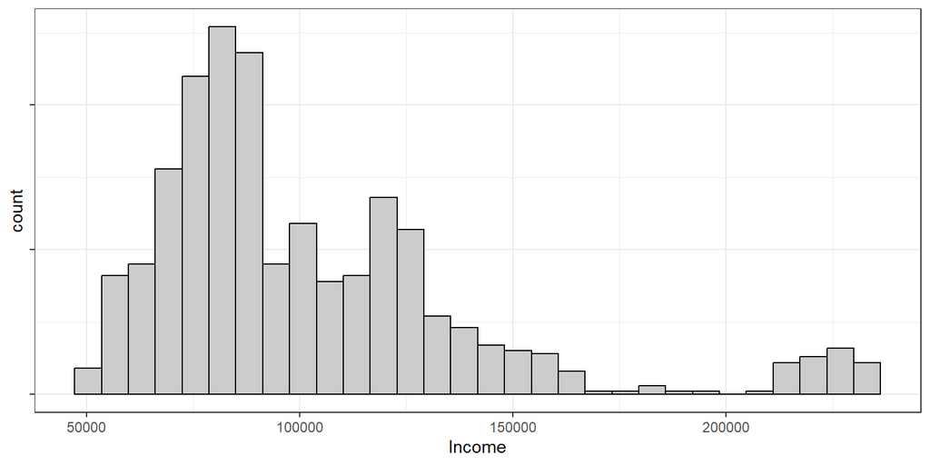

```r
# 5 number summary and mean
df %>% pull(x) %>% summary
```

```
##    Min. 1st Qu.  Median    Mean 3rd Qu.    Max.
##   51662   76283   89047  102449  120362  234359
```

```r
# std.dev
df %>% pull(x) %>% sd()
```

```
## [1] 38490.08
```

**Part A:** Use the histogram to describe this variable in a complete sentence as we learned in class. Make sure to include context.

**Part B:** Explain the concept of *robustness* as it applies to using statistics for describing a variable.

# Question 3

The table below presents the results from the 2006 General Social Survey conducted by the National Opinion Research Center polling 1,009 respondents on their age and level of job satisfaction. Row totals have been added in the last column.

**For the questions below, you do not need complete sentences but you must show the calculations used to derive your answer**

| Age | Job Satisfaction Low | Job Satisfaction Medium | Job Satisfaction High | Total Sum |
| --- | --- | --- | --- | --- |
| <30 | 34 | 53 | 88 | 175 |
| 30-50 | 80 | 174 | 304 | 558 |
| >50 | 29 | 75 | 172 | 276 |

**Part A:** What percentage of all respondents were between 30-50 years old and indicated that they had *low* job satisfaction?

**Part B:** Of those responsdents who were between 30-50 years old, what proportion indicated they had *low* job satisfaction.

**Part C:** Of those responsdents who had *low* job satisfaction, what proportion were between 30-50 years old?

**Part D:** Which age demographic had the highest proportion of respondents indicate that they had *high* job satisfaction?

**Part E:** Sketch a graphic/chart to display your results for Part D.

# Question 4 (Dragon Actuaries)

A fictitious pre-industrial kingdom has been having a string of bad luck recently: their villages and farmland keep getting attacked by fire-breathing dragons.

The ruler of this kingdom is trying to figure out if it is worth the money to hire mercenaries to guard the villages from dragons.

Damage assessors and actuaries have been running the data and they have come up with the following info to figure out how much damage to expect when a dragon attacks with or without mercenaries defending a village.

- The probability of a dragon burning down the village is 0.4
- The probability of mercenaries defend the village is 0.34
- The probability of mercenaries defending the village AND it burns down is 0.11
- The probability of the village burning down *given* there were no mercenaries to defend it is 0.44

Answer the following, providing values for probabilities. Show work using probability formulas to receive credit.

**Part A**: What is P(village not burning down)?

**Part B**: What is P(village burns AND no mercenaries defend)

**Part C**: What is P(village burns | mercenaries defend)

**Part D**: What is P(village burns down OR mercenaries defend the village)

**Part E**: According to the data are the events ‘mercenaries defend the town’ and ‘village burns down’ independent? Justify answer using appropriate probabilities.

**Part F**: Suppose you are a resident of a village in this kingdom. According to the data, would you want mercenaries to defend the village or not? Explain.

# Question 5

A study is designed to test the effect of light level and noise level on exam performance of college students. The light treatments considered are fluorescent overhead lighting, yellow overhead lighting, no overhead lighting (only desk lamps). The noise treatments considered are no noise, construction noise, and human chatter noise.

The researcher contacted a local college and 200 students volunteered to participate in the study. These students were randomly assigned to the treatments.

**Part A:** Is this an experiment or an observational study? Explain your answer.

**Part B:** What is an experimental unit in this study?

**Part C:** How many factors are considered in this study? Identify them, and describe their levels.

**Part D:** Does this study employ random sampling? Explain your answer.

**Part E:** Are the results of this study generalizable to all college students? Explain your answer.

**Part F:** Can we draw causal conclusions from the results of this study? Explain your answer.